# Assignment CFA SEM

Mohd Azmi

04/05/2020

# 1 Environment

## 1.1 Library

```r
library(pacman) #package management tool. run install.packages("pacman")
p_load(tidyverse, haven, summarytools, psych, MVN, lavaan, semTools, semPlot)
```

## 1.2 Dataset

dataset “exercise.sav” was imported directly into R, with vector name “exerciseds”

```r
exerciseds0 <- read_sav("Exercise.sav")
exerciseds <- exerciseds0 %>% mutate_if(is.labelled, ~(as_factor(.))) %>% print()
```

```
## # A tibble: 200 x 5
##       A1    A2   SP1   SP2 Exercise
##    <dbl> <dbl> <dbl> <dbl>    <dbl>
##  1     4     3     4     5        5
##  2     4     4     5     6        6
##  3     2     3     2     6        7
##  4     3     3     5     7        7
##  5     4     4     7     7        6
##  6     4     3     7     7        7
##  7     3     5     6     7        6
##  8     4     4     6     6        6
##  9     3     4     7     6        6
## 10     2     2     1     2        2
## # … with 190 more rows
```

# 2 Analysis

## 2.1 Step 0: Data Exploration

```r
descr(exerciseds)
```

```
## Descriptive Statistics
## exerciseds$Attitude 1
## Label: Attitude 1
## N: 200
##
##                         A1       A2   Exercise      SP1      SP2
## ----------------- -------- -------- ---------- -------- --------
##              Mean     3.48     3.52       5.82     6.28     6.57
##           Std.Dev     0.90     0.99       1.24     1.90     1.84
##               Min     1.00     1.00       1.00     1.00     1.00
##                Q1     3.00     3.00       5.00     5.00     5.50
##            Median     4.00     4.00       6.00     7.00     7.00
##                Q3     4.00     4.00       7.00     7.00     7.00
##               Max     5.00     5.00       7.00    10.00    10.00
##               MAD     1.48     1.48       1.48     1.48     1.48
##               IQR     1.00     1.00       2.00     2.00     1.25
##                CV     0.26     0.28       0.21     0.30     0.28
##          Skewness    -0.38    -0.51      -1.41    -0.48    -0.44
##       SE.Skewness     0.17     0.17       0.17     0.17     0.17
##          Kurtosis    -0.07     0.02       2.44     0.09     0.55
##           N.Valid   200.00   200.00     200.00   200.00   200.00
##         Pct.Valid   100.00   100.00     100.00   100.00   100.00
```

Variable A1 and A2 range from 1 - 5, while variable SP1 and SP2 range from 1 - 10 and variable Exercise range from 1 - 7.

There are 200 samples/records, in which no missing data.

## 2.2 Step 1: Model Conceptualisation

Not applicable. Model was given as in the question

## 2.3 Step 2: Path Diagram Construction

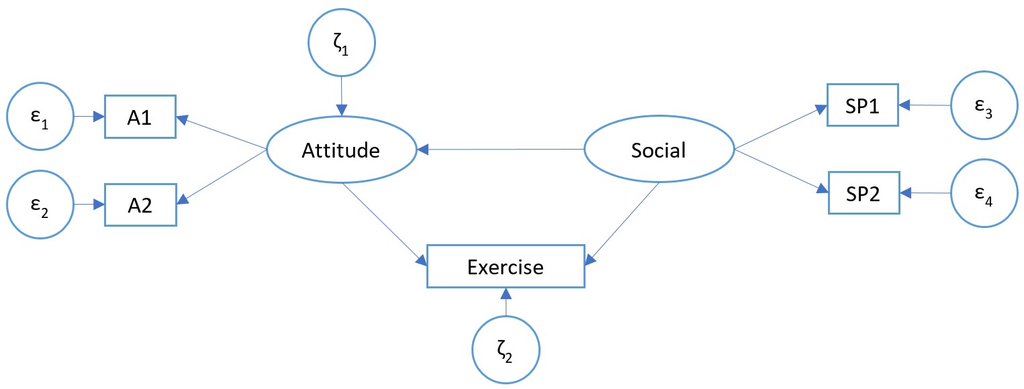

SEM Diagram

## 2.4 Step 3: Model Specification

model specification was named as “exermodspec”

```r
exermodspec <- "
Exercise ~ c*social + b*attitude
attitude =~ A1 + A2
social =~ SP1 + SP2
attitude ~ a*social
ab := a*b
total := c + a*b
"
```

## 2.5 Step 4: Model Identification

b - free information b= no of factor loading - 1 + no of error variance + no of factor variance + no of factor covariance + no of intercept =12

## 2.6 Step 5: Model Parameter Estimation

```r
exermodparam <- sem(exermodspec, data = exerciseds)
summary(exermodparam, fit.measure = T, standardized = T)
```

```
## lavaan 0.6-5 ended normally after 35 iterations
##
##   Estimator                                         ML
##   Optimization method                           NLMINB
##   Number of free parameters                         12
##
##   Number of observations                           200
##
## Model Test User Model:
##
##   Test statistic                                 6.464
##   Degrees of freedom                                 3
##   P-value (Chi-square)                           0.091
##
## Model Test Baseline Model:
##
##   Test statistic                               328.966
##   Degrees of freedom                                10
##   P-value                                        0.000
##
## User Model versus Baseline Model:
##
##   Comparative Fit Index (CFI)                    0.989
##   Tucker-Lewis Index (TLI)                       0.964
##
## Loglikelihood and Information Criteria:
##
##   Loglikelihood user model (H0)              -1523.960
##   Loglikelihood unrestricted model (H1)      -1520.728
##
##   Akaike (AIC)                                3071.920
##   Bayesian (BIC)                              3111.500
##   Sample-size adjusted Bayesian (BIC)         3073.483
##
## Root Mean Square Error of Approximation:
##
##   RMSEA                                          0.076
##   90 Percent confidence interval - lower         0.000
##   90 Percent confidence interval - upper         0.158
##   P-value RMSEA <= 0.05                          0.230
```

[output cut: 27 more lines]

```
##
## Variances:
##                    Estimate  Std.Err  z-value  P(>|z|)   Std.lv  Std.all
##    .A1                0.462    0.059    7.830    0.000    0.462    0.578
##    .A2                0.334    0.077    4.343    0.000    0.334    0.344
##    .SP1               1.636    0.237    6.907    0.000    1.636    0.455
##    .SP2               1.246    0.224    5.552    0.000    1.246    0.368
##    .Exercise          0.846    0.100    8.477    0.000    0.846    0.558
##    .attitude          0.127    0.041    3.078    0.002    0.377    0.377
##     social            1.963    0.363    5.401    0.000    1.000    1.000
##
## Defined Parameters:
##                    Estimate  Std.Err  z-value  P(>|z|)   Std.lv  Std.all
##     ab                0.165    0.108    1.525    0.127    0.231    0.187
##     total             0.570    0.074    7.737    0.000    0.799    0.649
```

Interpretation

standardized parameter

Mediation: the regression coefficient between attitude on exercise was not significant, thus there was no mediation.

## 2.7 Step 6: Assessment of Model Fit

```r
fitMeasures(exermodparam, c("RMSEA", "SRMR", "CFI", "TLI"))
```

```
## rmsea  srmr   cfi   tli
## 0.076 0.024 0.989 0.964
```

model seems fit

```r
residuals(exermodparam, type = "standardized.mplus")
```

```
## $type
## [1] "standardized.mplus"
##
## $cov
##          A1     A2     SP1    SP2    Exercs
## A1        0.000
## A2        0.000  0.000
## SP1       1.812 -1.363  0.000
## SP2       0.427 -0.617  0.000  0.000
## Exercise -2.694  1.621 -0.241  0.224  0.000
```

there was no large residual, with all standardized residual value lower than 4

```r
exermod_mi <- modificationIndices(exermodparam)
subset(exermod_mi, mi > 3.84)
```

```
##       lhs op      rhs    mi    epc sepc.lv sepc.all sepc.nox
## 19 social =~       A1 4.999  0.706   0.990    1.107    1.107
## 20 social =~       A2 4.999 -0.970  -1.359   -1.380   -1.380
## 24     A1 ~~ Exercise 4.999 -0.139  -0.139   -0.221   -0.221
## 27     A2 ~~ Exercise 4.999  0.190   0.190    0.358    0.358
```

## 2.8 Step 7: Model Respecification

not done due to model fit.

## 2.9 Step 8: Model Cross-validation

not done

## 2.10 SEM Plot

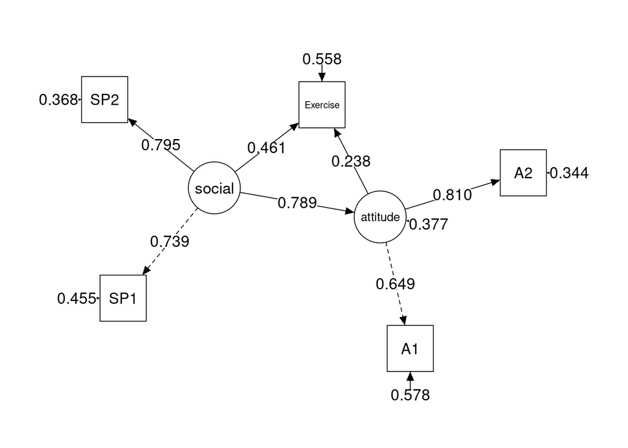

```r
exermod_semplot <- semPaths(exermodparam, what = "path", whatLabels = "std", layout = "spring",
                            edge.label.cex = 1.2, nDigits = 3, style = "lisrel", nCharNodes = 0,
                            sizeMan = 8, sizeLat = 9, edge.color = "black")
```

```r
#png("semplot.png", width = 1024, height = 720, res = 360)
#plot(exermod_semplot)
#dev.off()
```